# Projet R

  **On voit à clairement un rapport entre le classement de notre assureur sur un comparateur et le nombre d’assurés ayant souscrit via ce comparateur.**
- Analyse des choix des formules d’assurance par statut marital et pour chaque comparateur:

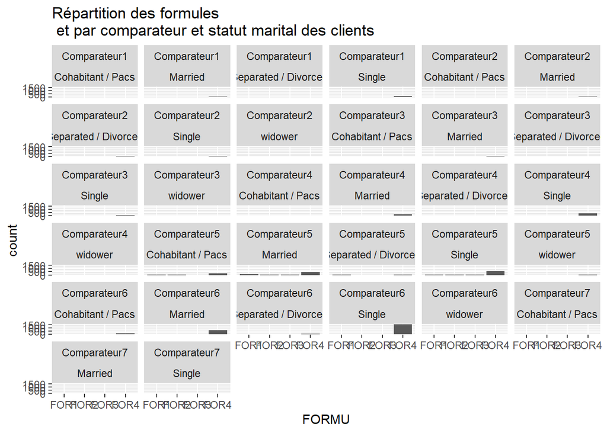

```r
ggplot(contra_comp, aes(x=FORMU))+

geom_bar()+facet_wrap(COMPAR~MARCLI)+ggtitle("Répartition des formules \n et par comparateur et statut marital des clients")
```

Remarque :

Qu’importe le comparateur et le statut marital, les assurés ont plus souscrit à la formule 4, elle reste la plus avantageuse pour nos assurés.

- Moyenne des primes par formule

```r
tab_form=contra_comp[,.(moy_prim=mean(AMTPREM),nombre=.N),by=.(FORMU)]

print(tab_form)
```

```
##    FORMU moy_prim nombre
## 1:  FOR1 2409.190    368
## 2:  FOR4 2484.656   5186
## 3:  FOR2 2458.055    164
## 4:  FOR3 2829.466    118
```

**Interprétations:**

```r
nbre_enfant=as.integer(!is.na(contra_comp$IDCHI1))+as.integer(!is.na(contra_comp$IDCHI2))+as.integer(!is.na(contra_comp$IDCHI3))+as.integer(!is.na(contra_comp$IDCHI4))+as.integer(!is.na(contra_comp$IDCHI5))+as.integer(!is.na(contra_comp$IDCHI6))
```

```r
contra_comp[,nombre_enfants:=nbre_enfant]
```

- Statistiques sur le nombre d’enfants

```r
summary(contra_comp$nombre_enfants)
```

```
##    Min. 1st Qu.  Median    Mean 3rd Qu.    Max.
##  0.0000  0.0000  0.0000  0.4673  1.0000  5.0000
```

```r
tab_enf=table(contra_comp$nombre_enfants)

print(tab_enf)
```

```
##
##    0    1    2    3    4    5
## 4204  727  746  130   27    2
```

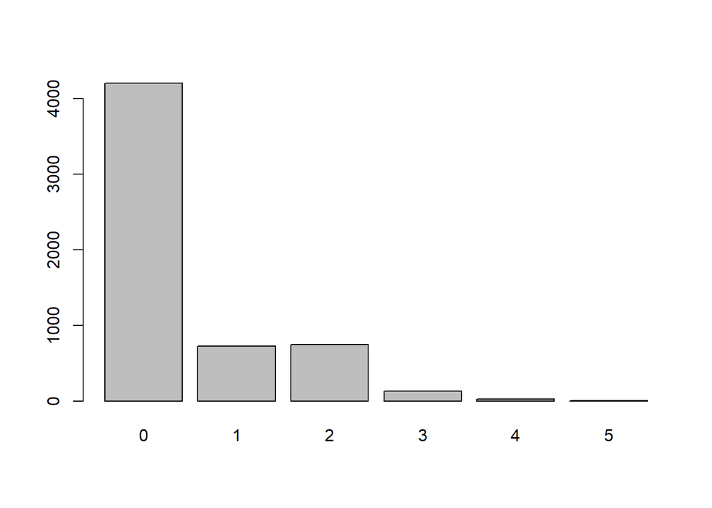

```r
barplot(table(contra_comp$nombre_enfants))
```

```r
tab_freq=tab_enf*100/nrow(contra_comp)

print(tab_freq)
```

```
##
##           0           1           2           3           4           5
## 72.03564085 12.45716244 12.78272790  2.22755312  0.46264565  0.03427005
```

Remarque:

- Nous allons donc analyser le choix des différentes formules et des comparateurs en fonction du nombre d’enfants de chaque client, pour ainsi voir si le nombre d’enfants influence le choix de la formule.

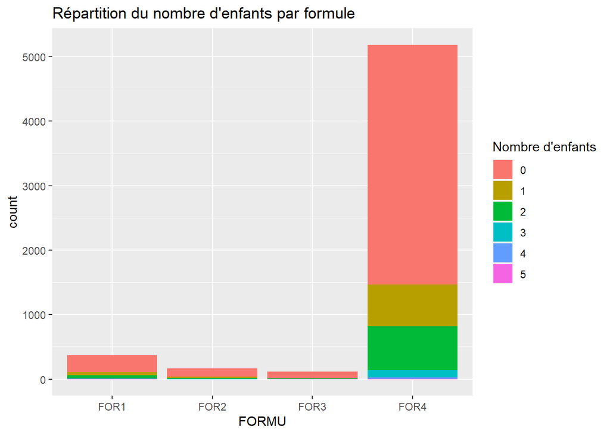

```r
ggplot(data=contra_comp,aes(x=FORMU,fill=as.factor(contra_comp$nombre_enfants)))+geom_bar()+labs(fill="Nombre d'enfants")+ggtitle("Répartition du nombre d'enfants par formule")
```

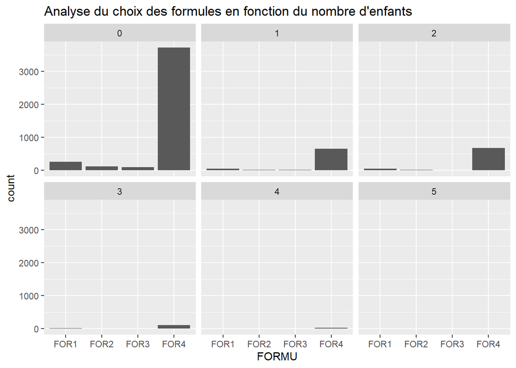

```r
ggplot(data=contra_comp,aes(x=FORMU))+geom_bar()+ggtitle("Analyse du choix des formules en fonction du nombre d'enfants")+facet_wrap(~nombre_enfants)
```

**Interprétation :**

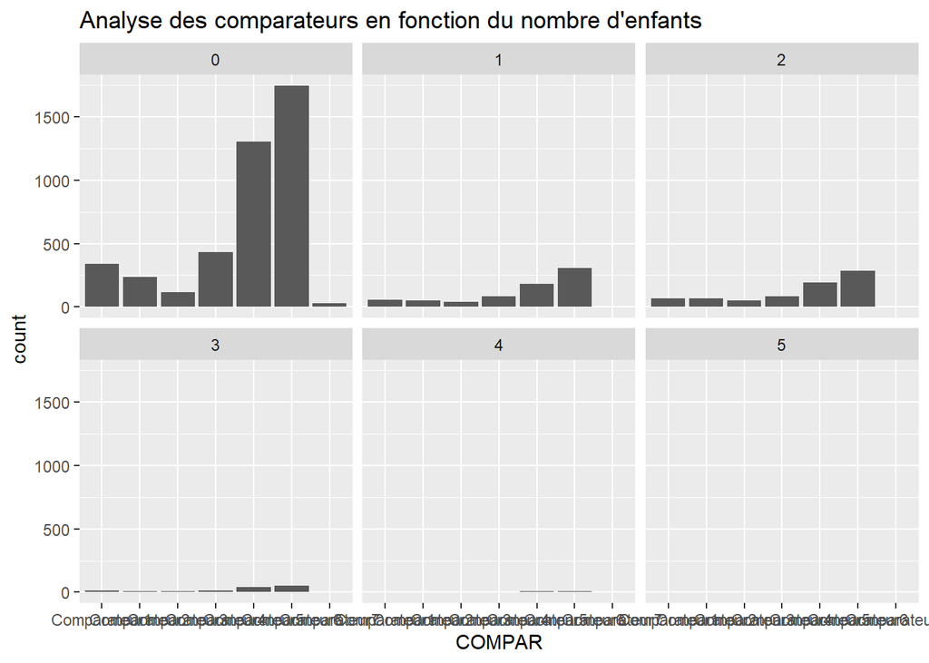

```r
ggplot(data=contra_comp,aes(x=COMPAR))+geom_bar()+ggtitle("Analyse des comparateurs en fonction du nombre d'enfants")+facet_wrap(~nombre_enfants)
```

**Interprétation:**

Le nombre d’enfants des clients n’a pas influencé le fait que la plus grande partie de nos assurés aient souscrit via les comparateurs 6 et 5.

5. Durée des contrats

```r
table(is.na(contra_comp$DATEEFF))
```

```
##
## FALSE
##  5836
```

Tous les contrats possèdent une date d’effet de garantie.

```r
table(is.na(contra_comp$DATECAN))
```

```
##
## FALSE  TRUE
##  1149  4687
```

Il y’a 4687 contrats sans date de résiliation et 1149 contrats résiliés.

```r
contra_comp[DATECAN=="NA",resilie:="Non"]
```

```r
contra_comp[is.na(DATECAN),resilie:="Non"]
```

```r
contra_comp[!is.na(DATECAN),resilie:="Oui"]
```

```r
table(contra_comp$resilie)
```

```
##
##  Non  Oui
## 4687 1149
```

- Création de la variable représentant la durée des contrats pour les contrats qui ont été résiliés:

```r
#clients ayant résilié leurs contrats

contra_resil=contra_comp[resilie=="Oui"]

print(contra_resil)
```

```
##            IDPOL    DATEEFF      IDCLI     IDPART     IDCHI1     IDCHI2 IDCHI3
##    1: 2C7EAEF380 2011-02-10 7A61ADDB61       <NA>       <NA>       <NA>   <NA>
##    2: F1125A72F9 2011-07-10 4E5D3AA63C 32D5615B20 2EF179B6C7 B09D69E316   <NA>
##    3: 0F5BF8EA40 2011-08-10 283B50C751       <NA>       <NA>       <NA>   <NA>
##    4: 73FB728155 2011-08-10 2DF3A65E55       <NA>       <NA>       <NA>   <NA>
##    5: 21BFCE62CB 2012-01-01 9C968CCD1F       <NA>       <NA>       <NA>   <NA>
##   ---
## 1145: CD2B50E2C8 2015-01-01 0459108AB7       <NA>       <NA>       <NA>   <NA>
## 1146: 75B344BC5B 2015-01-01 7BD50DF5BD 8C1E9ADB9E E3EBF67A08 0B47EABB20   <NA>
## 1147: 393975A549 2015-01-01 4C7F9A4B88       <NA>       <NA>       <NA>   <NA>
## 1148: DA3E2F195B 2015-01-01 E8E1D8AB93       <NA>       <NA>       <NA>   <NA>
## 1149: A240758C99 2015-01-01 66D9A5E612       <NA>       <NA>       <NA>   <NA>
##       IDCHI4 IDCHI5 IDCHI6 FORMU    DATECAN
##    1:   <NA>   <NA>     NA  FOR1 2017-12-31
##    2:   <NA>   <NA>     NA  FOR4 2016-12-31
```

[output cut: 45 more lines]

```r
#conversion de caractères en dates

date_deb=as.Date(contra_resil$DATEEFF,format = "%Y-%m-%d")

date_fin=as.Date(contra_resil$DATECAN,format = "%Y-%m-%d")

duree=date_fin-date_deb
```

```r
head(duree)
```

```
## Time differences in days
## [1] 2516 2001 1970 1970 1826 1848
```

```r
contra_resil[,dureeContra:=duree]

head(contra_resil)
```

```
##         IDPOL    DATEEFF      IDCLI     IDPART     IDCHI1     IDCHI2 IDCHI3
## 1: 2C7EAEF380 2011-02-10 7A61ADDB61       <NA>       <NA>       <NA>   <NA>
## 2: F1125A72F9 2011-07-10 4E5D3AA63C 32D5615B20 2EF179B6C7 B09D69E316   <NA>
## 3: 0F5BF8EA40 2011-08-10 283B50C751       <NA>       <NA>       <NA>   <NA>
## 4: 73FB728155 2011-08-10 2DF3A65E55       <NA>       <NA>       <NA>   <NA>
## 5: 21BFCE62CB 2012-01-01 9C968CCD1F       <NA>       <NA>       <NA>   <NA>
## 6: 0EF51BD7B0 2011-12-10 51305185AA       <NA>       <NA>       <NA>   <NA>
##    IDCHI4 IDCHI5 IDCHI6 FORMU    DATECAN                     REACAN AMTPREM
## 1:   <NA>   <NA>     NA  FOR1 2017-12-31 Non-payment of the premium    1455
## 2:   <NA>   <NA>     NA  FOR4 2016-12-31 Non-payment of the premium    4242
## 3:   <NA>   <NA>     NA  FOR2 2016-12-31 Non-payment of the premium    1977
## 4:   <NA>   <NA>     NA  FOR3 2016-12-31 Non-payment of the premium    3628
## 5:   <NA>   <NA>     NA  FOR4 2016-12-31 Non-payment of the premium    4738
## 6:   <NA>   <NA>     NA  FOR4 2016-12-31 Non-payment of the premium    4320
##    RANKAGG       COMPAR  MARCLI SEXCLI     DTNCLI  PROFCLI    CP SEXCJ
## 1:       1 Comparateur1  Single      M 1980-12-16 Employee 29200  <NA>
## 2:       4 Comparateur1 Married      M 1968-12-22 Employee  1700     F
## 3:       1 Comparateur1  Single      M 1977-06-08 Employee 45260  <NA>
## 4:       2 Comparateur1  Single      M 1960-09-05 Employee 74130  <NA>
## 5:       2 Comparateur1  Single      F 1951-02-19  Retired 14600  <NA>
## 6:       6 Comparateur1  Single      F 1962-07-12 Employee 66600  <NA>
##         DTNCJ   PROFCJ nombre_enfants resilie dureeContra
## 1:       <NA>     <NA>              0     Oui   2516 days
## 2: 1978-11-15 Employee              2     Oui   2001 days
## 3:       <NA>     <NA>              0     Oui   1970 days
## 4:       <NA>     <NA>              0     Oui   1970 days
## 5:       <NA>     <NA>              0     Oui   1826 days
## 6:       <NA>     <NA>              0     Oui   1848 days
```

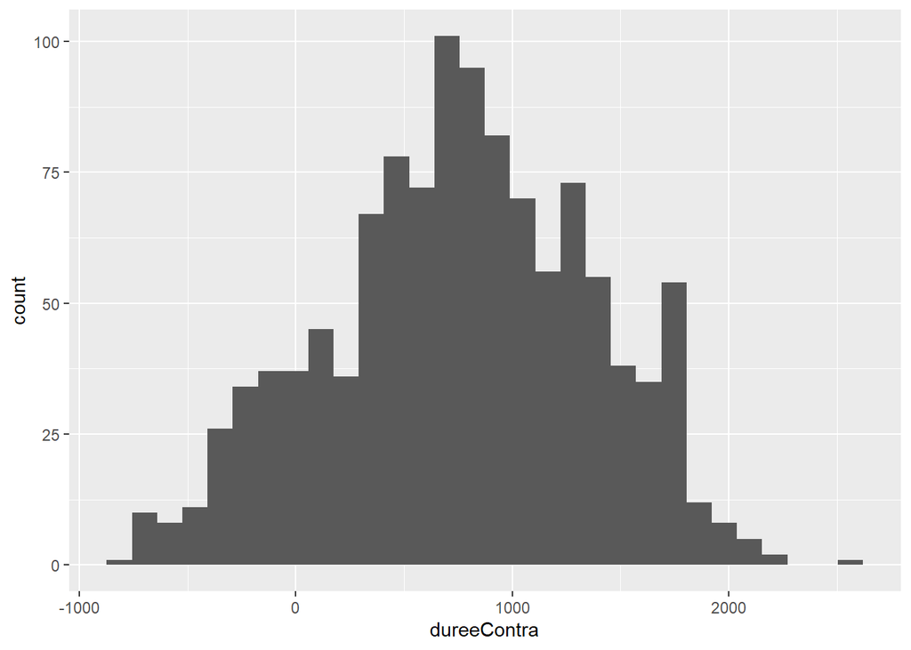

```r
#distribution de la durée des contrats

ggplot()+geom_histogram(data=contra_resil,aes(x = dureeContra))
```

Remarque:

Il y a des dates négatives, qui ne sont pas conformes. Il faut les retirer de la base de données.

```r
#les contrats non conformes

a=contra_resil[which(dureeContra<0)]

head(a[,dureeContra])
```

```
## Time differences in days
## [1] -320 -144  -46  -46  -47 -366
```

```r
contra_resil_clean=contra_resil[which(dureeContra>=0)]

head(contra_resil_clean)
```

```
##         IDPOL    DATEEFF      IDCLI     IDPART     IDCHI1     IDCHI2 IDCHI3
## 1: 2C7EAEF380 2011-02-10 7A61ADDB61       <NA>       <NA>       <NA>   <NA>
## 2: F1125A72F9 2011-07-10 4E5D3AA63C 32D5615B20 2EF179B6C7 B09D69E316   <NA>
## 3: 0F5BF8EA40 2011-08-10 283B50C751       <NA>       <NA>       <NA>   <NA>
## 4: 73FB728155 2011-08-10 2DF3A65E55       <NA>       <NA>       <NA>   <NA>
## 5: 21BFCE62CB 2012-01-01 9C968CCD1F       <NA>       <NA>       <NA>   <NA>
## 6: 0EF51BD7B0 2011-12-10 51305185AA       <NA>       <NA>       <NA>   <NA>
##    IDCHI4 IDCHI5 IDCHI6 FORMU    DATECAN                     REACAN AMTPREM
## 1:   <NA>   <NA>     NA  FOR1 2017-12-31 Non-payment of the premium    1455
## 2:   <NA>   <NA>     NA  FOR4 2016-12-31 Non-payment of the premium    4242
## 3:   <NA>   <NA>     NA  FOR2 2016-12-31 Non-payment of the premium    1977
## 4:   <NA>   <NA>     NA  FOR3 2016-12-31 Non-payment of the premium    3628
## 5:   <NA>   <NA>     NA  FOR4 2016-12-31 Non-payment of the premium    4738
## 6:   <NA>   <NA>     NA  FOR4 2016-12-31 Non-payment of the premium    4320
##    RANKAGG       COMPAR  MARCLI SEXCLI     DTNCLI  PROFCLI    CP SEXCJ
## 1:       1 Comparateur1  Single      M 1980-12-16 Employee 29200  <NA>
## 2:       4 Comparateur1 Married      M 1968-12-22 Employee  1700     F
## 3:       1 Comparateur1  Single      M 1977-06-08 Employee 45260  <NA>
## 4:       2 Comparateur1  Single      M 1960-09-05 Employee 74130  <NA>
## 5:       2 Comparateur1  Single      F 1951-02-19  Retired 14600  <NA>
## 6:       6 Comparateur1  Single      F 1962-07-12 Employee 66600  <NA>
##         DTNCJ   PROFCJ nombre_enfants resilie dureeContra
## 1:       <NA>     <NA>              0     Oui   2516 days
## 2: 1978-11-15 Employee              2     Oui   2001 days
## 3:       <NA>     <NA>              0     Oui   1970 days
## 4:       <NA>     <NA>              0     Oui   1970 days
## 5:       <NA>     <NA>              0     Oui   1826 days
## 6:       <NA>     <NA>              0     Oui   1848 days
```

Vérification

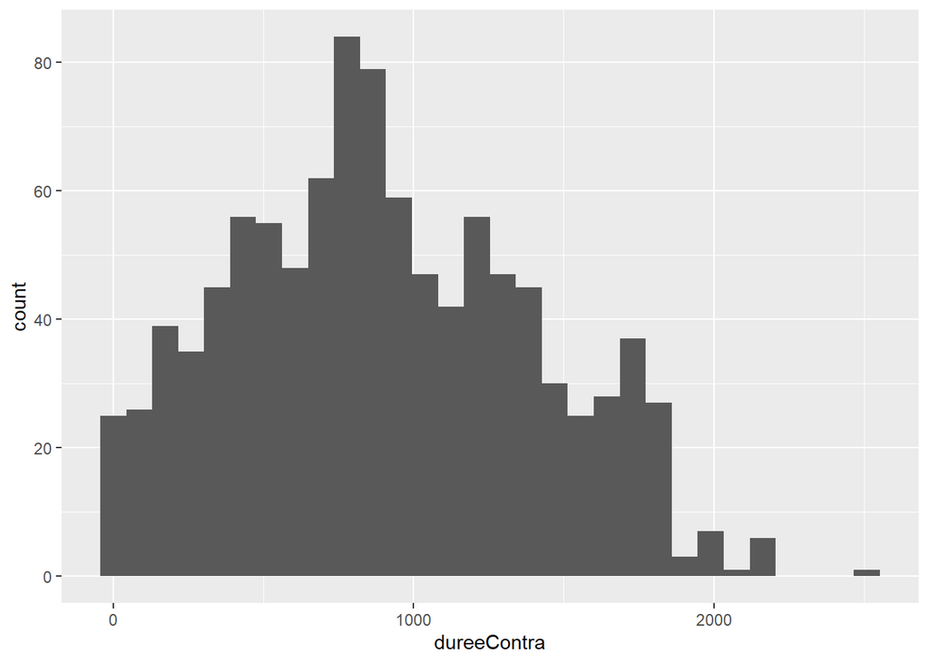

```r
ggplot()+geom_histogram(data=contra_resil_clean,aes(x=dureeContra))
```

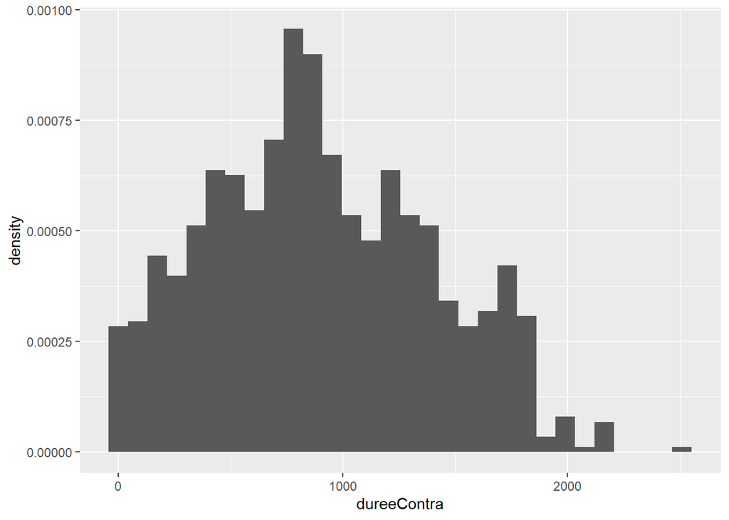

```r
 ggplot()+geom_histogram(data=contra_resil_clean,aes(x=dureeContra,y=..density..))+geom_density()
```

- Analyse de la durée de la contrats par formule:

```r
contra_resil_clean[,.(moyenne_duree=mean(dureeContra),moyenne_primes=mean(AMTPREM)),by=FORMU]
```

```
##    FORMU  moyenne_duree moyenne_primes
## 1:  FOR1 1058.8476 days       2417.229
## 2:  FOR4  869.7993 days       2392.611
## 3:  FOR2 1102.8367 days       2319.837
## 4:  FOR3  885.9118 days       2521.294
```

**Interprétation:**

```r
contra_resil_clean[,.(moyenne_duree=mean(dureeContra),moyenne_primes=mean(AMTPREM)),by=.(COMPAR)]
```

```
##          COMPAR  moyenne_duree moyenne_primes
## 1: Comparateur1 1064.6655 days       2317.109
## 2: Comparateur2  891.1818 days       2398.665
## 3: Comparateur3  924.5068 days       2323.438
## 4: Comparateur4  870.5975 days       2296.201
## 5: Comparateur5  784.8833 days       2422.417
## 6: Comparateur6  779.5037 days       2545.853
```

**Interprétations:**

- Le comparateur 1, bien que pas très convoité par les clients,est le comparateur où les contrats sont plus les plus longs, cela s’explique surement vu les prix des primes de chaque comparateur.
- les clients souscrivent le plus via les comparateurs 6 et 5,bien qu’offrant des primes relativement élevées.
6. fusion des tables contrats et prestations

Etude des montants des dépenses en fonction de plusieurs variables

```r
contra_prest=merge(contra_comp, prest, by = "IDPOL")
```

```r
head(contra_prest)
```

```
##         IDPOL    DATEEFF      IDCLI     IDPART     IDCHI1     IDCHI2 IDCHI3
## 1: 000B46F609 2018-06-01 C1B23F6425 52BA84B9C0 6C1EE86F8C D04BB97D0B   <NA>
## 2: 000B46F609 2018-06-01 C1B23F6425 52BA84B9C0 6C1EE86F8C D04BB97D0B   <NA>
## 3: 000B46F609 2018-06-01 C1B23F6425 52BA84B9C0 6C1EE86F8C D04BB97D0B   <NA>
## 4: 000B46F609 2018-06-01 C1B23F6425 52BA84B9C0 6C1EE86F8C D04BB97D0B   <NA>
## 5: 000B46F609 2018-06-01 C1B23F6425 52BA84B9C0 6C1EE86F8C D04BB97D0B   <NA>
## 6: 000B46F609 2018-06-01 C1B23F6425 52BA84B9C0 6C1EE86F8C D04BB97D0B   <NA>
##    IDCHI4 IDCHI5 IDCHI6 FORMU DATECAN REACAN AMTPREM RANKAGG       COMPAR
## 1:   <NA>   <NA>     NA  FOR4    <NA>   <NA>     296      NA Comparateur6
## 2:   <NA>   <NA>     NA  FOR4    <NA>   <NA>     296      NA Comparateur6
## 3:   <NA>   <NA>     NA  FOR4    <NA>   <NA>     296      NA Comparateur6
## 4:   <NA>   <NA>     NA  FOR4    <NA>   <NA>     296      NA Comparateur6
## 5:   <NA>   <NA>     NA  FOR4    <NA>   <NA>     296      NA Comparateur6
## 6:   <NA>   <NA>     NA  FOR4    <NA>   <NA>     296      NA Comparateur6
##     MARCLI SEXCLI     DTNCLI            PROFCLI    CP SEXCJ      DTNCJ
```

[output cut: 20 more lines]

```r
dep_compa=contra_prest[,.(moyenne_dep=mean(Amt)),by=COMPAR]

print(dep_compa)
```

```
##          COMPAR moyenne_dep
## 1: Comparateur6    17.71492
## 2: Comparateur5    18.48737
## 3: Comparateur4    21.05894
## 4: Comparateur1    13.61505
## 5: Comparateur3    42.21789
## 6: Comparateur2    26.55051
## 7: Comparateur7    25.99386
```

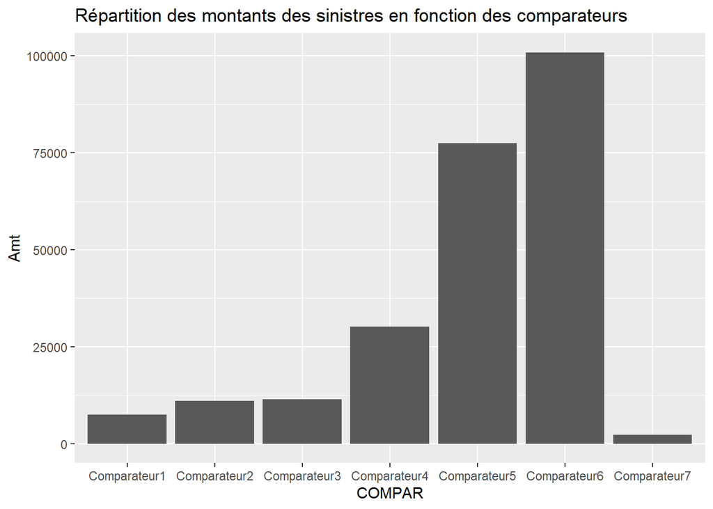

```r
ggplot(contra_prest, aes(x=COMPAR,y=Amt))+geom_bar(stat="identity")+ggtitle("Répartition des montants des sinistres en fonction des comparateurs")
```

**Interprétation**

- Les clients ayant choisi les comparateurs 4,5,6 sont ceux ayant les montants des sinsitres les plus élévés.
- on peut aussi remarquer que le montant des dépenses évolue en fonction du comparateur à l’exception du comparateur 7.

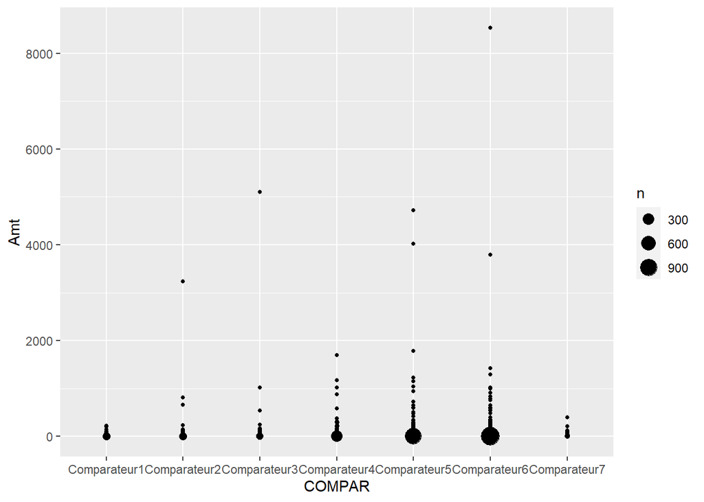

```r
ggplot(contra_prest, aes(x=COMPAR,y=Amt))+geom_count()
```

** Interpréation**

- Ce graphique confirme bien les obervations relevées concernant les montants des dépenses par comparateur.

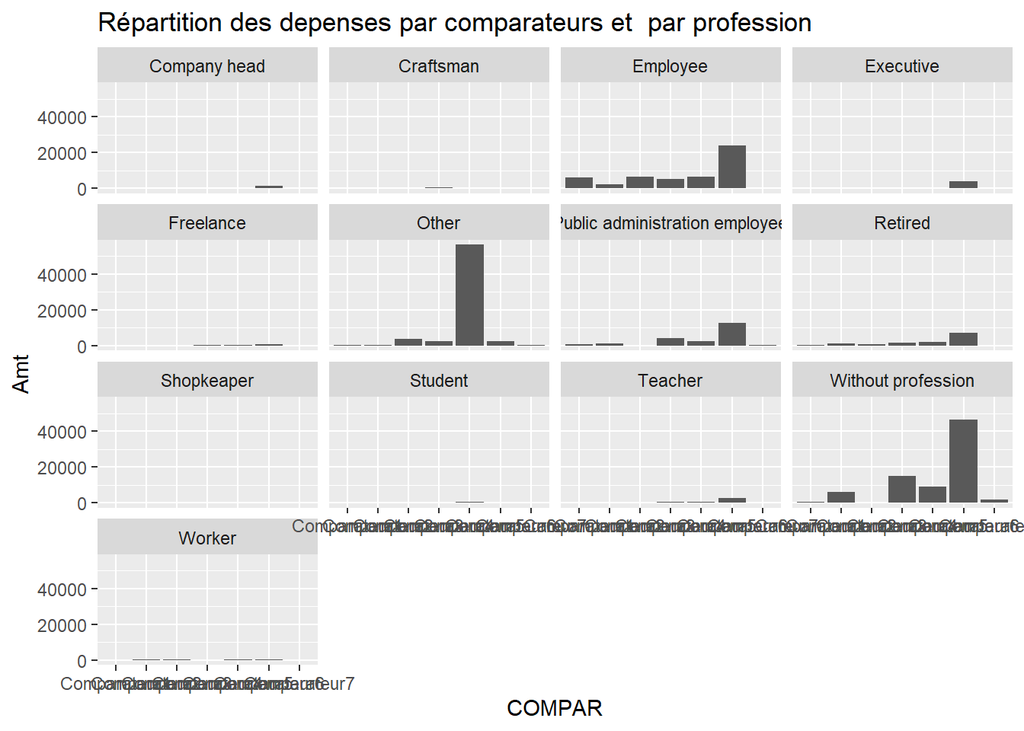

```r
ggplot(contra_prest, aes(x=COMPAR,y=Amt))+geom_bar(stat="identity")+facet_wrap(~PROFCLI)+ggtitle("Répartition des depenses par comparateurs et  par profession")
```

**Interprétation**

- on remarque qu’importe la profession , le comparateur 6 est celui qui génère le plus de dépenses à l’exception des personnes ayant “autre” comme profession .
- les employés , sans profession et autres sont ceux qui génèrent le plus de dépenses peu importe le comparateur.

```r
tab_depen=contra_prest[,.(moyenne_dep=mean(Amt)),by=MARCLI]

print(tab_depen)
```

```
##                  MARCLI moyenne_dep
## 1:              Married   18.593123
## 2:               Single   20.276958
## 3:    Cohabitant / Pacs   18.765869
## 4: Separated / Divorced   13.352569
## 5:              widower    6.387708
```

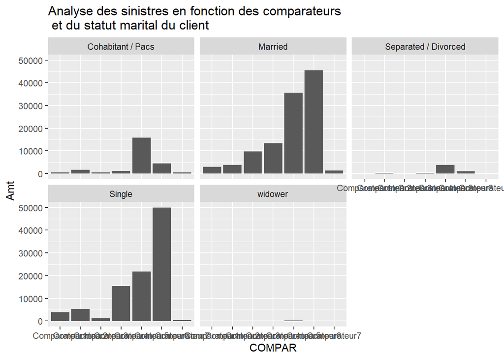

```r
ggplot(contra_prest, aes(x=COMPAR,y=Amt))+

geom_bar(stat="identity")+facet_wrap(~MARCLI)+ggtitle("Analyse des sinistres en fonction des comparateurs \n et du statut marital du client")
```

**Interprétation**

- Les célibataires et les mariés sont les catégories qui génèrent le plus de dépenses . Celles-ci sont plus élevées pour le comparateur 6 par ailleurs.
- Les couples de la catégorie “Cohabitant/pacs” et “séparés/divorcé” ont des dépenses plus élévées pour ceux ayant choisi le comparateur 5.